# ICON-CH1-EPS Full Horizontal Field with Polytope & earthkit

The following notebook demonstrates the full workflow to access, process and visualize ICON-CH1-EPS model data on the full horizontal field using 2-meter temperature data.

[figure not shown]

The data is retrieved using [Polytope](https://polytope.readthedocs.io/en/latest/), a feature extraction software developed by ECMWF. It applies concepts of computational geometry to extract n-dimensional polygons (also known as polytopes) from datacubes, also including the full horizontal field. Follow the instructions to learn more about model data access via Polytope.

## Installation

Follow the instructions in [README.md](https://github.com/MeteoSwiss/nwp-fdb-polytope-demo/blob/main/README.md#Installation-1) to install the necessary dependencies.

## Configuring Access to Polytope

To access ICON data via MeteoSwiss's Polytope, you need a Polytope offline token provided by MeteoSwiss. If you do not already have a token, you can request one [here](https://meteoswiss.atlassian.net/wiki/spaces/IW2/pages/327780397/Polytope#Offline-token-authentication). Then, create a new `config.yml` file based on `config_example.yml`, and replace <meteoswiss_key> with your access token there.

```python
import os
os.environ['ECCODES_ECKIT_GEO'] = "1"  # before importing eccodes, enable ICON native grid support
os.environ["ECCODES_VERSION_CHECK_OFF"] = "1"  # disable warning about eccodes version mismatch
import eccodes
import eccodes_cosmo_resources

vendor = eccodes.codes_definition_path()
cosmo = eccodes_cosmo_resources.get_definitions_path()
eccodes.codes_set_definitions_path(f"{cosmo}:{vendor}")
```

```python
import yaml
import os

def load_config(path="config.yml"):
    if not os.path.exists(path):
        raise FileNotFoundError("Missing config.yml. Please create one based on config_example.yml")
    with open(path, "r") as f:
        return yaml.safe_load(f)

config = load_config()

#ICON-CSCS Polytope credentials
os.environ["POLYTOPE_USER_KEY"] = config["meteoswiss"]["key"]
os.environ["POLYTOPE_ADDRESS"] = "https://service.meteoswiss.ch/polytope"
```

## Selecting date and time of the forecast

The FDB containing real-time data typically **holds only the most recent day of forecasts**. Therefore, it is necessary to specify the current date and select a corresponding forecast time in the past.

```python
from datetime import datetime, timedelta

# Current time
now = datetime.now()

# Subtract 12 hours
past_time = now - timedelta(hours=12)

# Round down to the nearest multiple of 6
rounded_hour = (past_time.hour // 6) * 6
rounded_time = past_time.replace(hour=rounded_hour, minute=0, second=0, microsecond=0)

# Format as YYYYMMDD and HHMM
date = rounded_time.strftime('%Y%m%d')
time = rounded_time.strftime('%H%M')
date,time
```

```
('20261009', '0000')
```

## Define the request

While other notebooks in this folder demonstrate how to use Polytope for feature extraction (e.g., extracting subsets or regions of interest), this example shows that we can also access the full horizontal grid directly via Polytope. To access the data containing the complete horizontal field, we need to define a MARS request **without** the `feature` key.

This example fetches **2-m temperature** from **ICON-CH1-EPS** at the **surface**, for the **control forecast** (`type="cf"`), at the selected run date/time.

```python
request = {
    'param': 'T_2M',
    'date': date,
    'time': time,
    'expver': '0001',
    'step': 0,
    'class': 'od',
    'levtype': 'sfc',
    'model': 'icon-ch1-eps',
    'stream': 'enfo',
    'type': 'cf',
    'timespan': 'none'
}
```

## Data retrieval

Now we use [earthkit.data](https://earthkit-data.readthedocs.io/en/latest/) to load the data and convert it into an [xarray.Dataset](https://docs.xarray.dev/en/stable/generated/xarray.Dataset.html). When requesting the full horizontal field data, make sure to use the `mch` collection rather than `mchgj` (used for feature extraction). Retrieving the full field requires a different collection setup, so be careful to adapt the collection accordingly.

```python
import earthkit.data as ekd
ds = ekd.from_source(
    "polytope",
    "mch",
    request,
    stream=False
)
```

```
2026-10-09 17:55:15 - INFO - Sending request...
{'request': 'class: od\n'
            "date: '20261009'\n"
            "expver: '0001'\n"
            'levtype: sfc\n'
            'model: icon-ch1-eps\n'
            'param: T_2M\n'
            'step: 0\n'
            'stream: enfo\n'
            "time: '0000'\n"
            'timespan: none\n'
            'type: cf\n',
 'verb': 'retrieve'}
2026-10-09 17:55:15 - INFO - Request accepted. Please poll ./62769849-a57f-4487-91b6-fa0bc8c74ddb for status
2026-10-09 17:55:15 - INFO - Checking request status (62769849-a57f-4487-91b6-fa0bc8c74ddb)...
2026-10-09 17:55:15 - INFO - The current status of the request is 'queued'
2026-10-09 17:55:16 - INFO - The current status of the request is 'processing'
2026-10-09 17:55:18 - INFO - The current status of the request is 'processed'
```

```python
fl = ds.to_fieldlist()
fl[0]
```

Field

data

| **number_of_values** | 1147980 |
| --- | --- |
| **array_type** | ndarray |
| **array_dtype** | float64 |

parameter

| **variable** | T_2M |
| --- | --- |
| **standard_name** | air_temperature |
| **long_name** | 2m Temperature |
| **units** | kelvin |

time

| **valid_datetime** | 2026-10-09 00:00:00 |
| --- | --- |
| **base_datetime** | 2026-10-09 00:00:00 |
| **step** | 0:00:00 |

vertical

| **level** | 2 |
| --- | --- |
| **layer** | None |
| **level_type** | height_above_ground_level |

ensemble

| **member** | 0 |
| --- | --- |

geography

| **grid_spec** | {'grid': 'ICON-CH1_C', 'uid': '17643da2574959b644d254a3cd6e2bc0'} |
| --- | --- |
| **grid_type** | ICON |
| **shape** | (1147980,) |
| **area** | (50.6, -0.9, 41.9, 17.8) |

> **NOTE**: The next cell may raise an exception when trying to download the grid file. While the bug is not fixed yet, you can download the file, rename and move it to the expected location manually. The URL (`sites.ecmwf.int/...`), filename (`<long hash>.ek`) and expected location (`$HOME/.local/share/eckit/geo/grid/icon/`) can be found in the error message.

```python
fl[0].metadata("gridSpec")
```

```
'{"grid":"ICON-CH1_C","uid":"17643da2574959b644d254a3cd6e2bc0"}'
```

You can get the latitude and longitude of all the gridpoints:

```python
fl.geography.latlons()
```

```
Downloading 'https://sites.ecmwf.int/repository/eckit/geo/grid/icon-ch/icon-ch1-c.ek' to '/users/nnellen/.cache/eckit/geo/latlon/1/b0699f374c63d05028c18c12f80a48f4.ek'...
Read  rate: 13.8421 Mbytes per second
Write rate: 855.88 Mbytes per second
Save into: 1 second elapsed, 0.12937 second cpu
Download of 17.5866 Mbytes took 1.75207s.
```

```
(array([50.24126072, 50.23908677, 50.23668743, ..., 50.05725025,
        50.04884147, 50.04392089], shape=(1147980,)),
 array([17.71062114, 17.6892742 , 17.70257141, ..., 12.80605782,
        12.80909967, 12.8018857 ], shape=(1147980,)))
```

Or convert to xarray:

```python
fl[0].to_xarray()
```

```
<xarray.Dataset> Size: 28MB
Dimensions:    (values: 1147980)
Coordinates:
    latitude   (values) float64 9MB ...
    longitude  (values) float64 9MB ...
Dimensions without coordinates: values
Data variables:
    T_2M       (values) float64 9MB ...
Attributes:
    Conventions:  CF-1.8
    institution:  ECMWF
```

## Plotting

We use the library [earthkit.plots](https://earthkit-plots.readthedocs.io/en/latest/) to plot the data. Moreover, we can specify a styling with [earthkit.plots.styles](https://earthkit-plots.readthedocs.io/en/latest/examples/guide/04-styles.html#4.-Styles) to show a color spectrum from red to blue and convert the unit to Celsius for better readability.

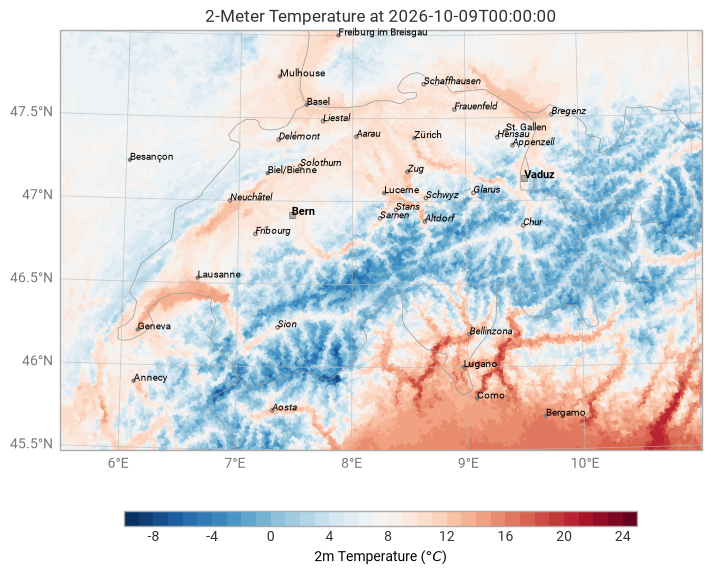

```python
from earthkit.plots import Map
from earthkit.plots.styles import Style
from earthkit.plots.styles.levels import Levels
from earthkit.plots.geography import bounds, domains
import cartopy.crs as ccrs
import matplotlib.ticker as mticker

xmin, xmax = 5.5, 11   # Longitude bounds
ymin, ymax = 45.5, 48   # Latitude bounds

bbox = bounds.BoundingBox(xmin, xmax, ymin, ymax, ccrs.Geodetic())
domain = domains.Domain.from_bbox(
    bbox=bbox,
    name="CH2"
)

style = Style(
    colors="RdBu_r",
    units="celsius",
    levels=Levels(step=1),
    ticks=mticker.MaxNLocator(nbins='auto'),
)
chart = Map(domain=domain)
chart.point_cloud(fl[0], x="longitude", y="latitude", style=style)

chart.coastlines()
chart.borders()
chart.cities("high")
chart.gridlines()

chart.title(f"2-Meter Temperature at {rounded_time.isoformat()}")
chart.legend()
chart.show()
```